# Exploratory data analysis and summarization of white wine data

Let’s check similarly for Density and Residual Sugar whether they have any effect on the total quality of the wine.

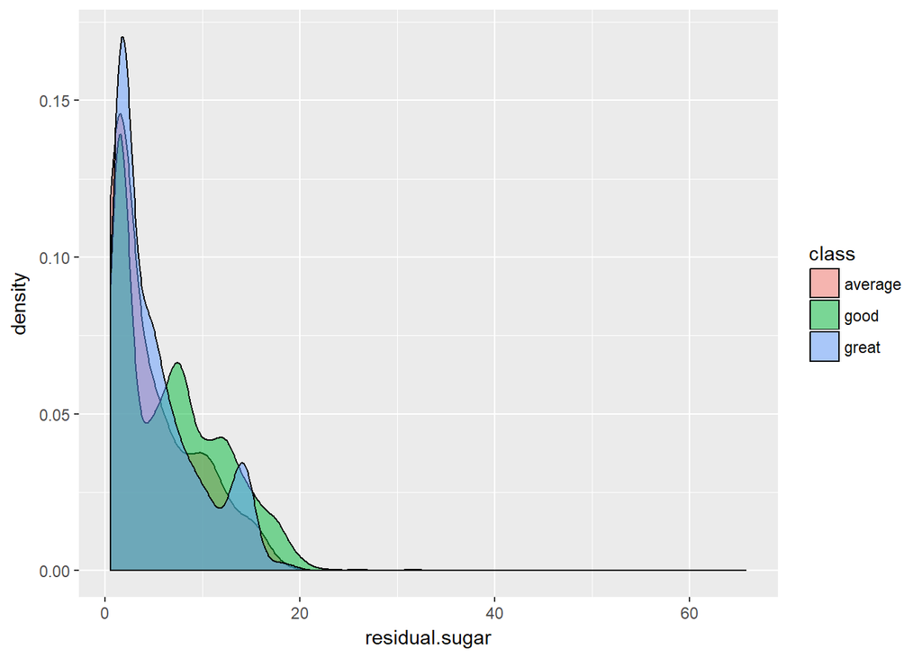

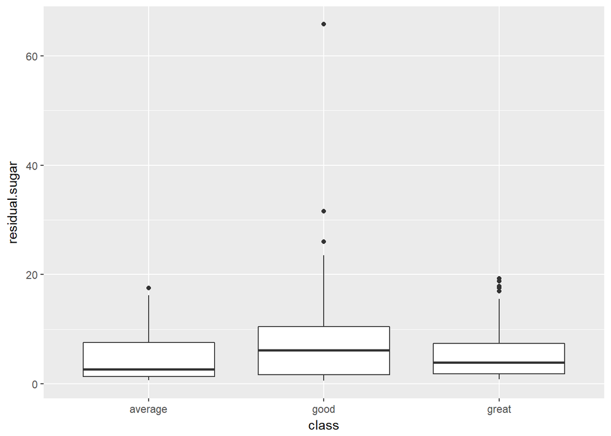

```
## [1] 0.8389729
```

There is a strong correlation between residual sugar and density which can help us check for density vs quality.

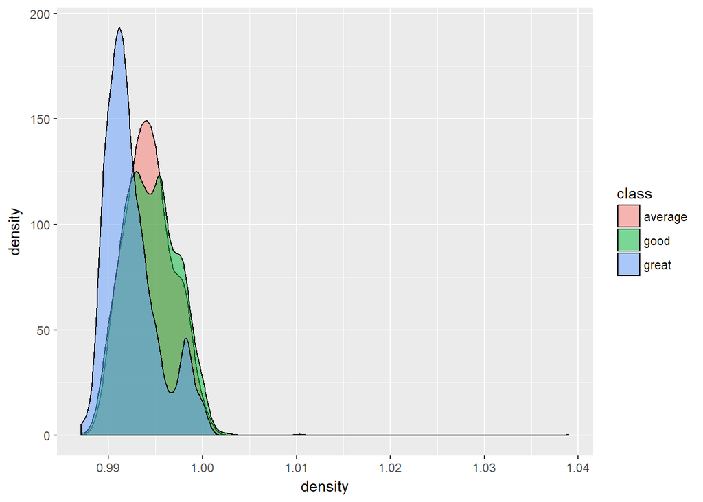

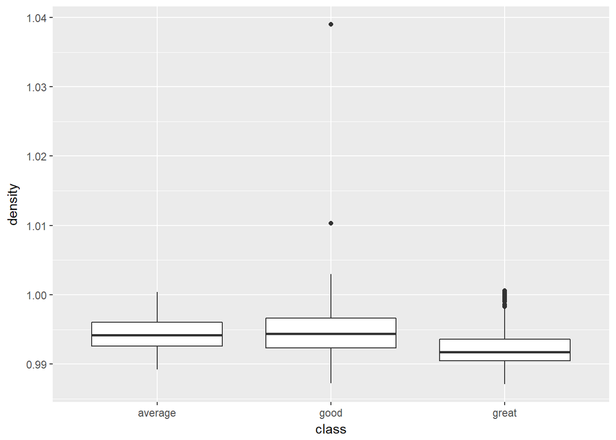

As we can see that lower density better wine. As once famous wine drinker said “It’s wine not a soup!”

We also saw a relation between alcohol and density. This relation can be seen on the graph below.

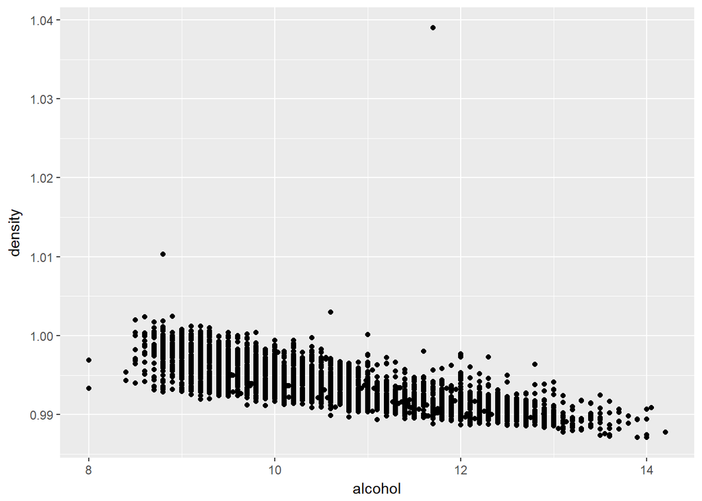

We also check for relation between residual sugar and density for further inference.

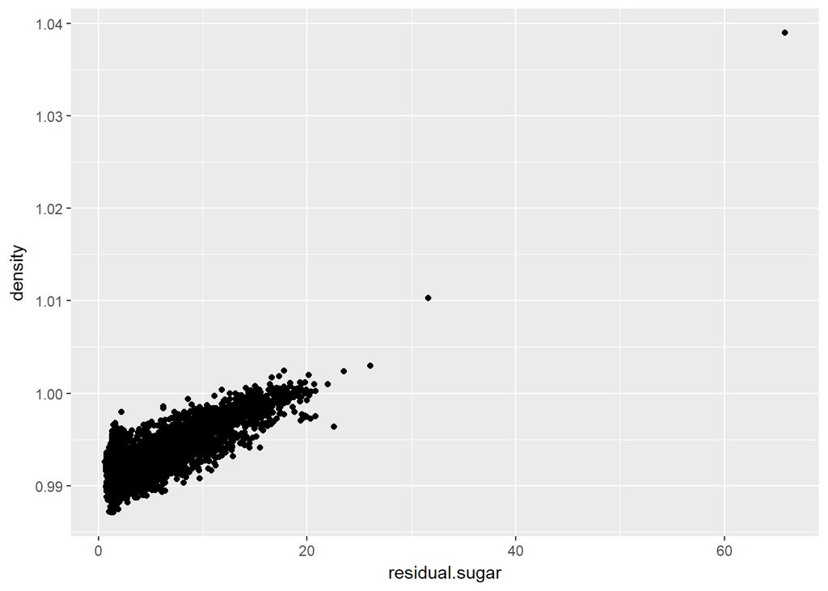

Here is the plot (above) which shows relation between residual sugar and density.

There is a negative relation between density and alcohol which seems to be the case so as to why great wines have lower density and higher alcohol concentration as well as lower SO2 levels(free and total).

Our analysis proves that , Better wines are bound to have a control on alcohol level and SO2 level and since they use more concentrated alcohol they’re bound to have a lower density. Since they tend to have a lower density they also tend to have lower residual sugar.

## Multivariate Analysis

We’ll be using facet grid to have further confidence with what we’re going with. Previously we saw quality of wines are affected by parameters such as density , alcohol and total sulphate dioxide as well as free sulphate dioxide. We were further able to see how average wines are basically an uneven mixture of components. We here would further try to diffrentiate and establish our confidence on how to make the best wine! Maybe our wine features in a movie with actress holding it up and saying well , This is the best bottle of wine i’ve ever had. Let’s try to understand more in this component. But , We’re going to tweak things up. We won’t be using the classification used previously but identify on the basis of “quality parameter”.

Our first analysis is going to be focusing upon factors which weren’t covered in bivariate analysis. We start of with **pH and Ratio( free SO2 VS total SO2**

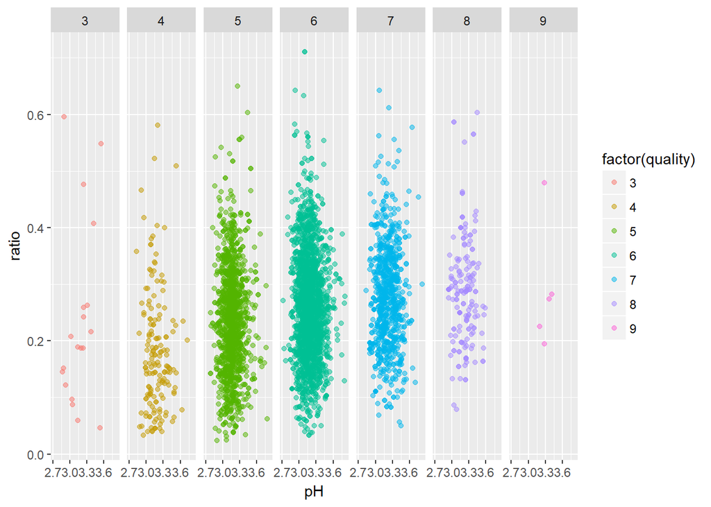

So , How about **pH and residual sugar** ?

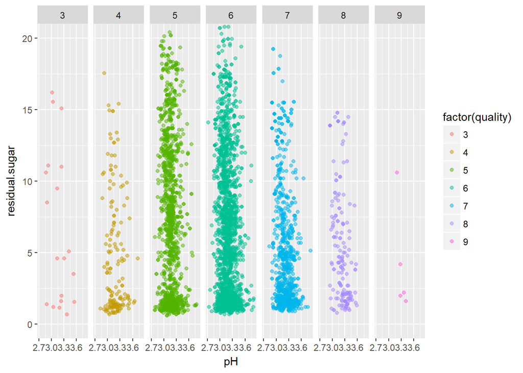

As seen previously in bivariate analysis that lower residual sugar results in great wines. The good wines have a scattered residual sugar rates. Which can further mean that residual sugar along a certain pH range gives a better wine. As seen in quality 8. The qualuty 5 & 6 have higher residual sugar while also having a scattered pH range.

**The total sulphate would be the next thing which we would be checking on the basis of pH.**

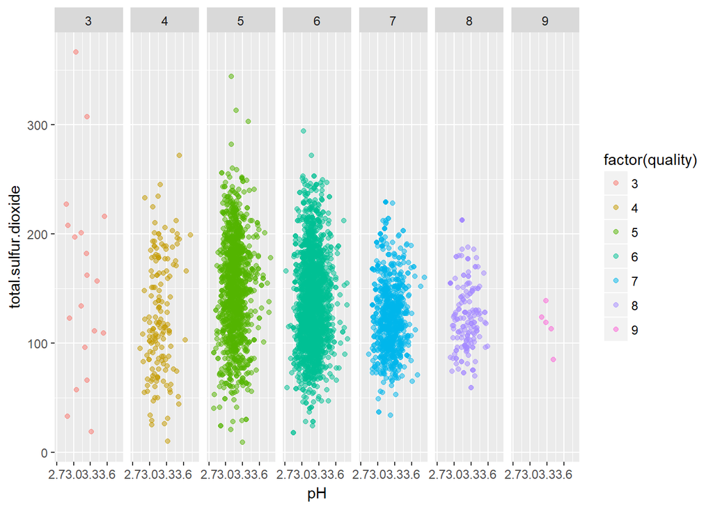

As established previously , Better wines have a range of total sulphate somewhere in between 50-250

Similarly for free sulphate dioxide

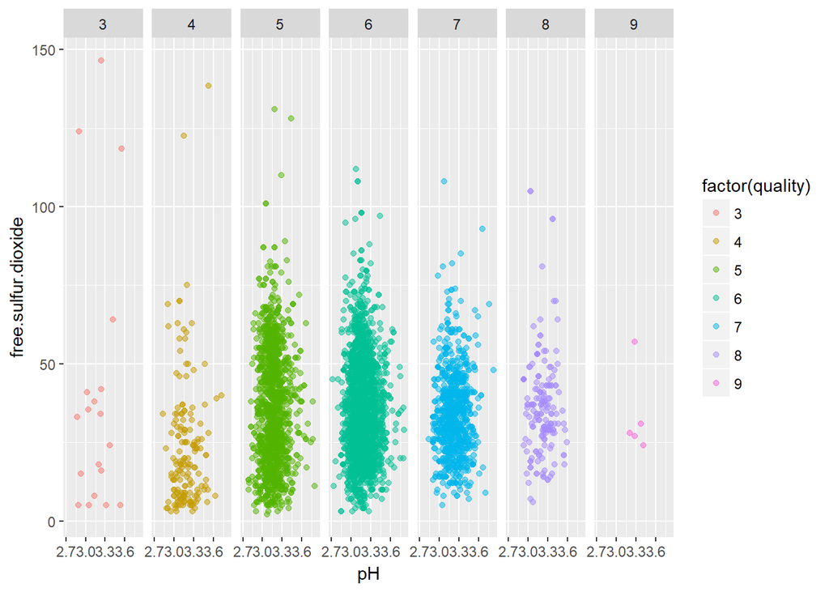

Similar to our previous observation. There is a particular range of pH as well as total and free sulphate dioxide which makes the wine great!

** Sulphates and Ratio** Our groundbreaking discovery ?

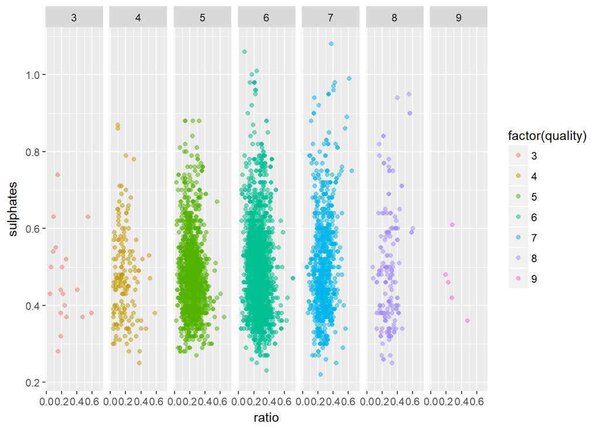

Sadly , No. There is nothing concrete to infer from the above graph apart from the fact that lower quality wine have lower ration as compared to moderate as well higher quality wine having a moderate ratio rate. As far as Sulphate is concerned we can see that all types of wines have a standard limit for sulphates. **So is it just alcohol and SO2 levels ?**

Total Sulpher dioxide graph is plotted below,

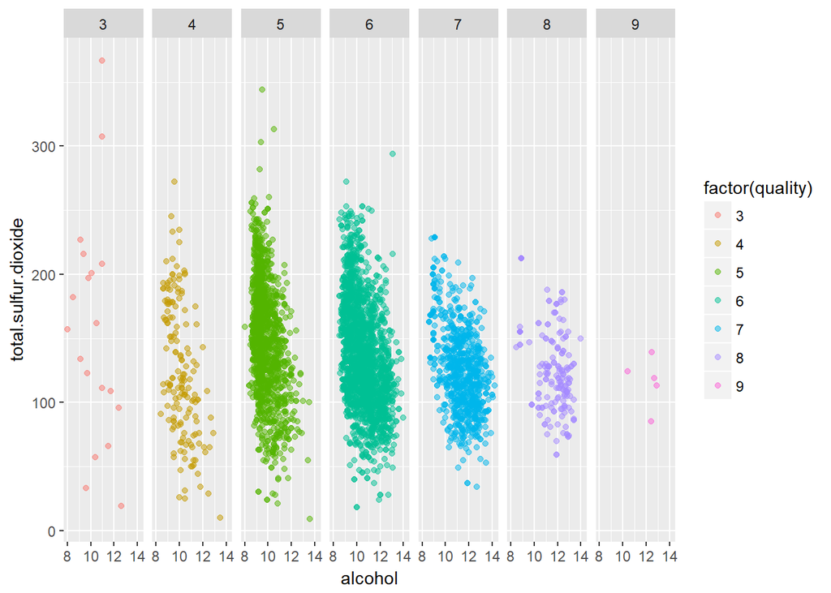

Interstingly , We can see that higher alcohol concentration along with lower SO2 levels gives a better wine.

Let’s check for free sulphur dioxide ,

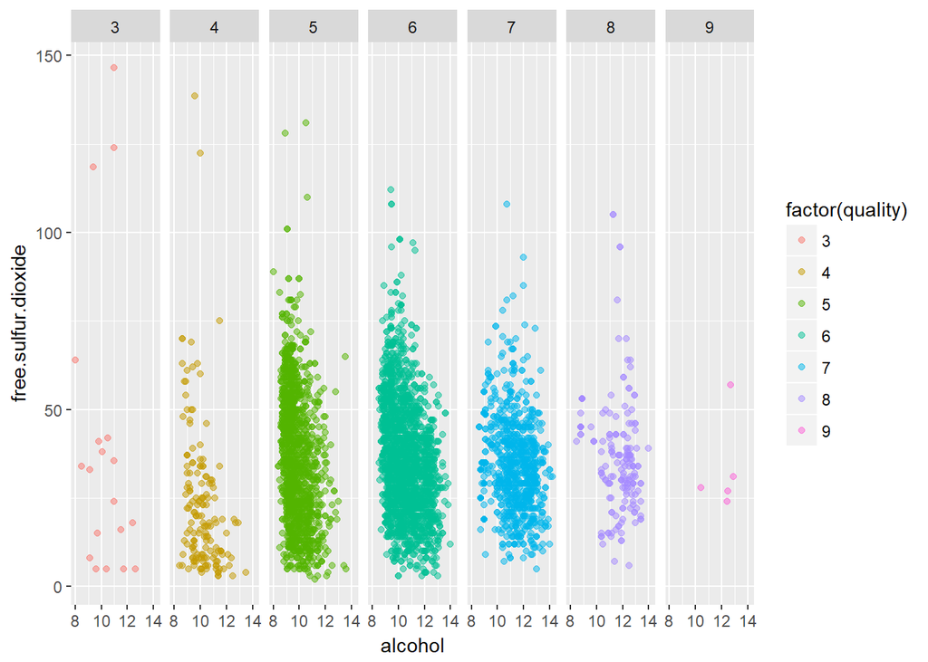

Not surprising at all. Our final inference could be well restricted to the fact that , Quality is heavily dependent on Alcohol Concentration as well as Total and free sulphate dioxide.

## Final Summary

The key takeway could be the fact that restricted Sulphate dioxide rates along with higher concetration of Alcohol yields in better wine quality as shown below ,

** Plot - 1 **

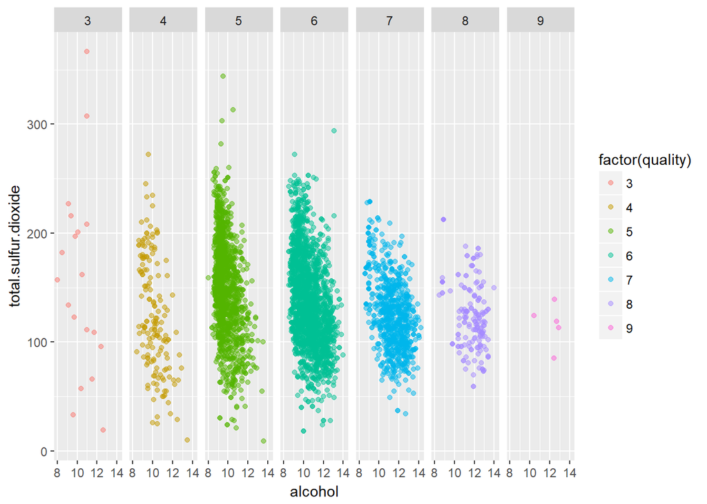

In this , graph you could see that lower total sulpher dioxide along with higher level of alcohol gives a better wine! which actually makes sense , Since alcohol would yield in lower ratio but what’s further surprising is the fact that there is a correlation between total sulpher dioxide and density. The correlation isn’t a strong one but can be said that there is an effect. Here is the correlation :-

```
## [1] 0.5330658
```

Which can be seen on the graph below ,

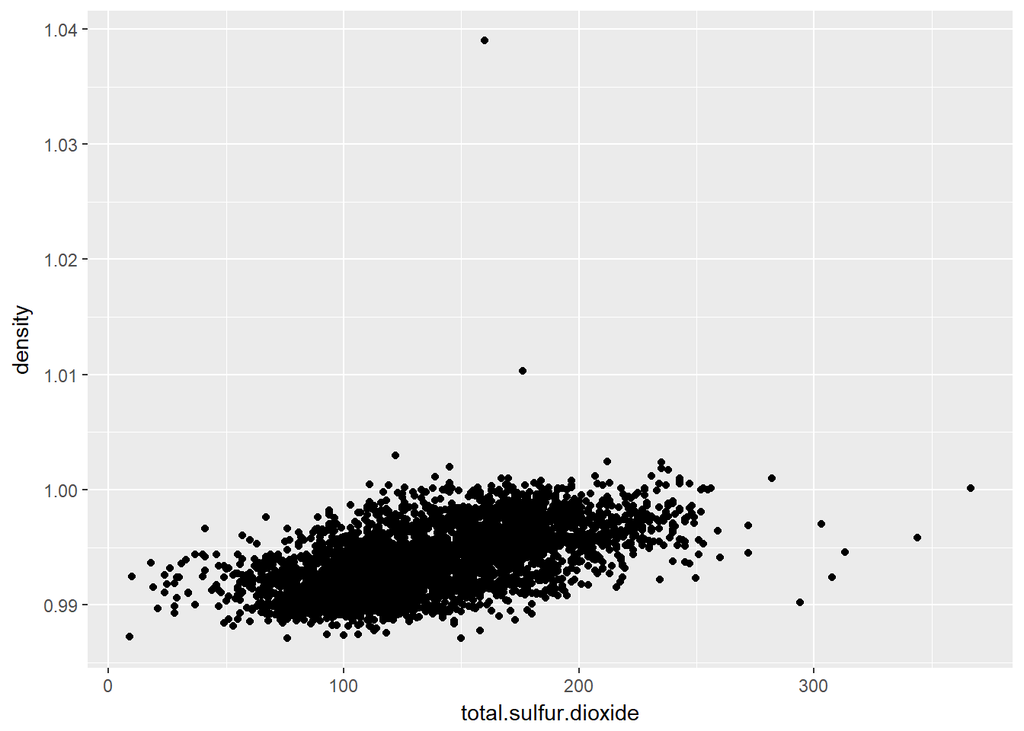

Similarly for the free sulphur dioxide ,

```
## [1] 0.3020608
```

** Plot - 2 **

The density problem , We saw lower density had a great affect on the quality of wine. Let’s check this graph to assess more.

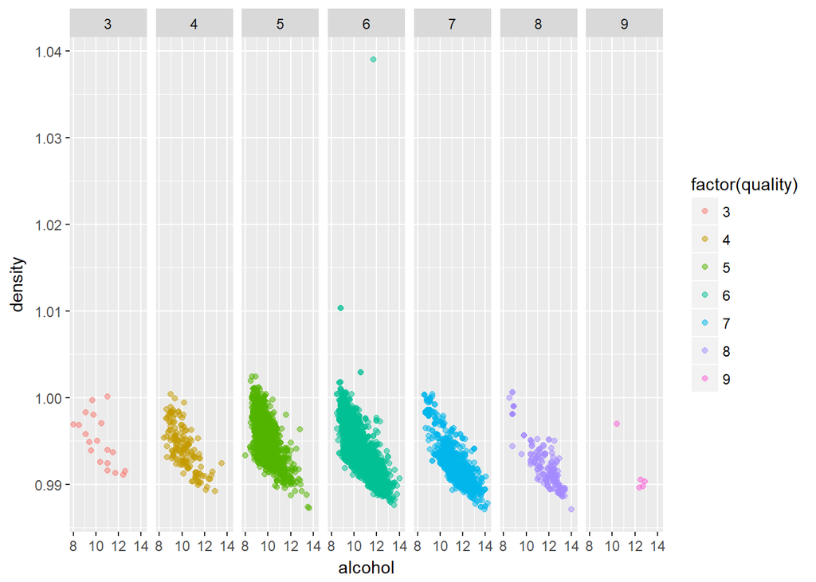

We can see that there is a good relation , But is it strong enough to infer ? No , We can come to a conclusion again with respect to alcohol that lower concentration of alcohol means a lower quality wine. Whilst a lower density wine is better and we saw from the correlation graph previously that alcohol concentration has adverse affect on the density

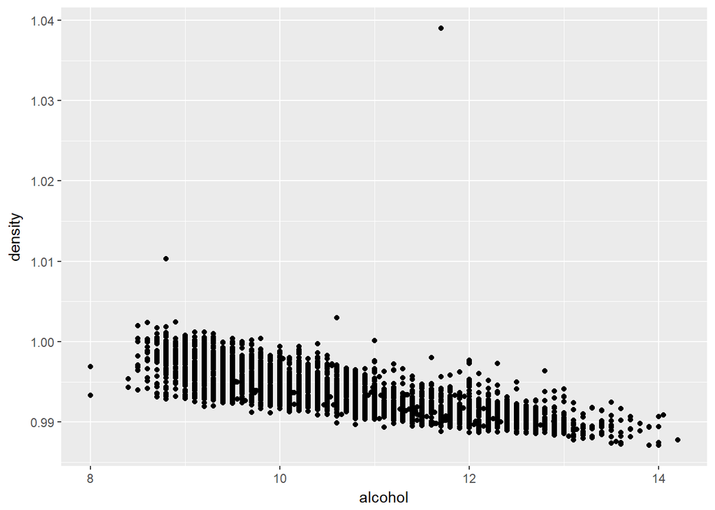

** Plot - 3 **

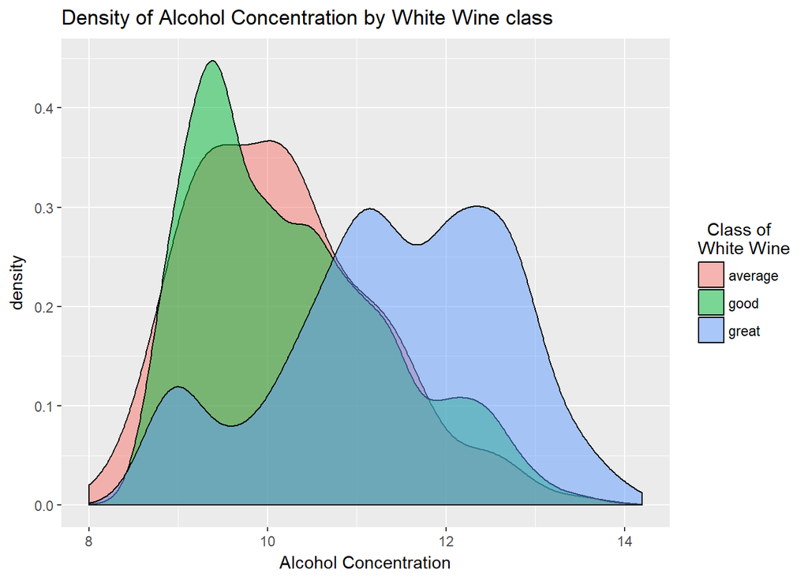

Here , We were able to segreate the lower quality wine from the better quality wines. Which resulted in further analysis.

The statistics for the very same is mentioned below ,

For average wines :

```
##    Min. 1st Qu.  Median    Mean 3rd Qu.    Max.
##    8.00    9.40   10.10   10.17   10.80   13.50
```

for good wines :

```
##    Min. 1st Qu.  Median    Mean 3rd Qu.    Max.
##    8.00    9.40   10.00   10.27   11.00   14.00
```

for great wines :

```
##    Min. 1st Qu.  Median    Mean 3rd Qu.    Max.
##    8.50   10.70   11.50   11.42   12.40   14.20
```

These statistics were important to reach the conclusion.

## CONCLUSION

Finally our quest to search for the best possible combination to build a great wine ends. We have found out that alcohol has a huge impact on the overall quality of wine.

Apart from alcohol we saw that sulphur dioxide free and total had infuence on the wine being great. The chemical aspects of wine affect the quality of wine.

We also found that there was a specific pH range and ratio of the sulphur dioxide affecting the entire quality of wine along with the alcohol concentration.

The future research can further be based on different parameters such as aging of wine , temperature which can affect the density in turn affect the quality of wine. Also , There was a strong feeling that if further more data could’ve been gathered it would’ve enriched our conclusion and could have given a much better conclusion.